```r
library(data.table)
library(ggplot2)
library(lubridate)
# install.packages("kableExtra")
library(knitr)
library(kableExtra)
```

### Assumed constants

```r
# https://github.com/midas-network/COVID-19/blob/master/parameter_estimates/2019_novel_coronavirus/estimates.csv

ICU_LOS = 9
ACUTE_LOS = 7
DAYS_FROM_SYMPTOMS_TO_HOSP = 6
PREV_DT = 6
```

### Load COVID Tracking Time Series Data by State on Cases and Hospitalizations

For states with any hospitalizedCumulative data that is identical to hospitalizedCurrently, only use the hospitalizedCurrently data. For states with only hospitalizedCumulative data that is never identical to hospitalizedCurrently, use hospitalizedCumulative data. For states with no hospitalizedCumulative, use only hospitalizedCurrently if available.

```r
raw_dt = fread('data/daily-covidtracker-0404.csv')[,.(date, state, positive, hospitalizedCurrently, hospitalizedCumulative)]
raw_dt = raw_dt[!is.na(hospitalizedCurrently) | !is.na(hospitalizedCumulative)]
raw_dt[, date := as.Date(as.character(date), format = '%Y %m %d')]

state_data_types = raw_dt[,.(
  useHospitalizedCurrently = pmax(
    min(ifelse(!is.na(hospitalizedCumulative), 0, 1)),
    max(
    c(ifelse(hospitalizedCumulative == hospitalizedCurrently, 1, 0),0), na.rm = TRUE))
  ), by = 'state']

raw_dt = merge(raw_dt, state_data_types)
raw_dt[useHospitalizedCurrently == 1, hospitalizedCumulative := NA]
raw_dt[,useHospitalizedCurrently := NULL]

raw_dt[state == "CA"] %>% kable() %>% kable_styling()
```

| state | date | positive | hospitalizedCurrently | hospitalizedCumulative |
| --- | --- | --- | --- | --- |
| CA | 2020-04-04 | 12026 | 2300 | NA |
| CA | 2020-04-03 | 10701 | 2188 | NA |
| CA | 2020-04-02 | 9191 | 1922 | NA |
| CA | 2020-04-01 | 8155 | 1855 | NA |
| CA | 2020-03-31 | 7482 | 1617 | NA |
| CA | 2020-03-30 | 6447 | 1432 | NA |
| CA | 2020-03-29 | 5708 | 1034 | NA |
| CA | 2020-03-28 | 4643 | 1034 | NA |
| CA | 2020-03-27 | 3879 | 746 | NA |

### Load Our Data on (Expected % of Cases Hospitalized, and Expected % of Hospitalizations in ICU) by County

Aggregate to State-level and combine with Covid Tracking time series

```r
county_estimates = fread('data/county_age_severity_rates_v6.csv')

state_agg = county_estimates[,.(
  state_population = sum(population_in_age_group),
  wtd_critical_case_rate =  weighted.mean(critical_case_rate, population_in_age_group),
  wtd_acute_case_rate =  weighted.mean(severe_cases_rate, population_in_age_group)
  ), by = 'State']

state_abbrev = fread('data/state_abbrev.csv')[,.(State, Code)]

state_agg = merge(state_abbrev, state_agg, by = 'State')
state_agg = state_agg[,.(
  state = Code,
  state_population,
  exp_prop_hosp_in_icu = ICU_LOS*wtd_critical_case_rate/(ICU_LOS*wtd_critical_case_rate+ACUTE_LOS*wtd_acute_case_rate),
  exp_prop_cases_hos = wtd_critical_case_rate + wtd_acute_case_rate
  )]

state_agg %>% kable() %>% kable_styling()
```

| state | state_population | exp_prop_hosp_in_icu | exp_prop_cases_hos |
| --- | --- | --- | --- |
| AL | 4864680 | 0.3611620 | 0.0728536 |
| AK | 738516 | 0.3070323 | 0.0594195 |
| AZ | 6946685 | 0.3701946 | 0.0719562 |
| AR | 2990671 | 0.3665662 | 0.0721470 |
| CA | 39148760 | 0.3493473 | 0.0661899 |
| CO | 5531141 | 0.3388134 | 0.0662268 |
| CT | 3581504 | 0.3689069 | 0.0757854 |
| DE | 949495 | 0.3663666 | 0.0764244 |
| DC | 684498 | 0.3369685 | 0.0610181 |
| FL | 20598139 | 0.3889573 | 0.0815067 |
| GA | 10297484 | 0.3360362 | 0.0650482 |
| HI | 1422029 | 0.3785443 | 0.0750363 |
| ID | 1687809 | 0.3573852 | 0.0680004 |
| IL | 12821497 | 0.3581274 | 0.0700571 |
| IN | 6637426 | 0.3584701 | 0.0700123 |
| IA | 3132499 | 0.3767625 | 0.0732518 |
| KS | 2908776 | 0.3663775 | 0.0693705 |
| KY | 4440204 | 0.3566786 | 0.0717877 |
| LA | 4663616 | 0.3518923 | 0.0685007 |
| ME | 1332813 | 0.3757650 | 0.0838364 |
| MD | 6003435 | 0.3501494 | 0.0703946 |
| MA | 6830193 | 0.3643359 | 0.0735064 |
| MI | 9957488 | 0.3644694 | 0.0742530 |
| MN | 5527358 | 0.3602706 | 0.0708289 |
| MS | 2988762 | 0.3562193 | 0.0693892 |
| MO | 6090062 | 0.3664460 | 0.0730646 |
| MT | 1041732 | 0.3700499 | 0.0770009 |
| NE | 1904760 | 0.3675282 | 0.0691997 |
| NV | 2922849 | 0.3469394 | 0.0694797 |
| NH | 1343622 | 0.3605222 | 0.0782417 |
| NJ | 8881845 | 0.3619384 | 0.0730358 |
| NM | 2092434 | 0.3653841 | 0.0721824 |
| NY | 19618453 | 0.3647079 | 0.0725284 |
| NC | 10155624 | 0.3551984 | 0.0710851 |
| ND | 752201 | 0.3715142 | 0.0682487 |
| OH | 11641879 | 0.3663545 | 0.0739021 |
| OK | 3918137 | 0.3607114 | 0.0688876 |
| OR | 4081943 | 0.3633328 | 0.0742762 |
| PA | 12791181 | 0.3768509 | 0.0773543 |
| RI | 1056611 | 0.3724280 | 0.0753384 |
| SC | 4955925 | 0.3603599 | 0.0738609 |
| SD | 864289 | 0.3724149 | 0.0713408 |
| TN | 6651089 | 0.3567203 | 0.0718104 |
| TX | 27885195 | 0.3343842 | 0.0609522 |
| UT | 3045350 | 0.3320692 | 0.0540195 |
| VT | 624977 | 0.3691260 | 0.0803374 |
| VA | 8413774 | 0.3495834 | 0.0696871 |
| WA | 7294336 | 0.3508452 | 0.0695623 |
| WV | 1829054 | 0.3741721 | 0.0804689 |
| WI | 5778394 | 0.3648416 | 0.0737622 |
| WY | 581836 | 0.3550700 | 0.0705211 |

```r
state_ts = merge(raw_dt, state_agg)
state_ts[state == "CA"] %>% kable() %>% kable_styling()
```

| state | date | positive | hospitalizedCurrently | hospitalizedCumulative | state_population | exp_prop_hosp_in_icu | exp_prop_cases_hos |
| --- | --- | --- | --- | --- | --- | --- | --- |
| CA | 2020-04-04 | 12026 | 2300 | NA | 39148760 | 0.3493473 | 0.0661899 |
| CA | 2020-04-03 | 10701 | 2188 | NA | 39148760 | 0.3493473 | 0.0661899 |
| CA | 2020-04-02 | 9191 | 1922 | NA | 39148760 | 0.3493473 | 0.0661899 |
| CA | 2020-04-01 | 8155 | 1855 | NA | 39148760 | 0.3493473 | 0.0661899 |
| CA | 2020-03-31 | 7482 | 1617 | NA | 39148760 | 0.3493473 | 0.0661899 |
| CA | 2020-03-30 | 6447 | 1432 | NA | 39148760 | 0.3493473 | 0.0661899 |
| CA | 2020-03-29 | 5708 | 1034 | NA | 39148760 | 0.3493473 | 0.0661899 |
| CA | 2020-03-28 | 4643 | 1034 | NA | 39148760 | 0.3493473 | 0.0661899 |
| CA | 2020-03-27 | 3879 | 746 | NA | 39148760 | 0.3493473 | 0.0661899 |

### Convert hospitalizedCurrently to hospitalizedCumulative with assumptions about % in ICU vs Floor, and LOS for each

```r
state_ts[,exp_agg_los := ICU_LOS*exp_prop_hosp_in_icu + ACUTE_LOS*(1-exp_prop_hosp_in_icu)]
state_ts[!is.na(hospitalizedCumulative), imputed_cum_hos := FALSE]
state_ts[is.na(hospitalizedCumulative), `:=`(
  hospitalizedCumulative = hospitalizedCurrently/(1 - 2^(-1*exp_agg_los/PREV_DT)),
  imputed_cum_hos = TRUE
  )]


state_ts = state_ts[,.(state, date, state_population,  exp_prop_cases_hos, positive, hospitalizedCumulative, imputed_cum_hos)]
state_ts[state == "CA"] %>% kable() %>% kable_styling()
```

| state | date | state_population | exp_prop_cases_hos | positive | hospitalizedCumulative | imputed_cum_hos |
| --- | --- | --- | --- | --- | --- | --- |
| CA | 2020-04-04 | 39148760 | 0.0661899 | 12026 | 3904 | TRUE |
| CA | 2020-04-03 | 39148760 | 0.0661899 | 10701 | 3714 | TRUE |
| CA | 2020-04-02 | 39148760 | 0.0661899 | 9191 | 3262 | TRUE |
| CA | 2020-04-01 | 39148760 | 0.0661899 | 8155 | 3148 | TRUE |
| CA | 2020-03-31 | 39148760 | 0.0661899 | 7482 | 2744 | TRUE |
| CA | 2020-03-30 | 39148760 | 0.0661899 | 6447 | 2430 | TRUE |
| CA | 2020-03-29 | 39148760 | 0.0661899 | 5708 | 1755 | TRUE |
| CA | 2020-03-28 | 39148760 | 0.0661899 | 4643 | 1755 | TRUE |
| CA | 2020-03-27 | 39148760 | 0.0661899 | 3879 | 1266 | TRUE |

```r
table(state_ts$imputed_cum_hos)
```

```
##
## FALSE  TRUE
##   351   115
```

### Plot Cumulative Hospitalizations and Cumulative Positive Results by State

Only plot states with at least 5 data points

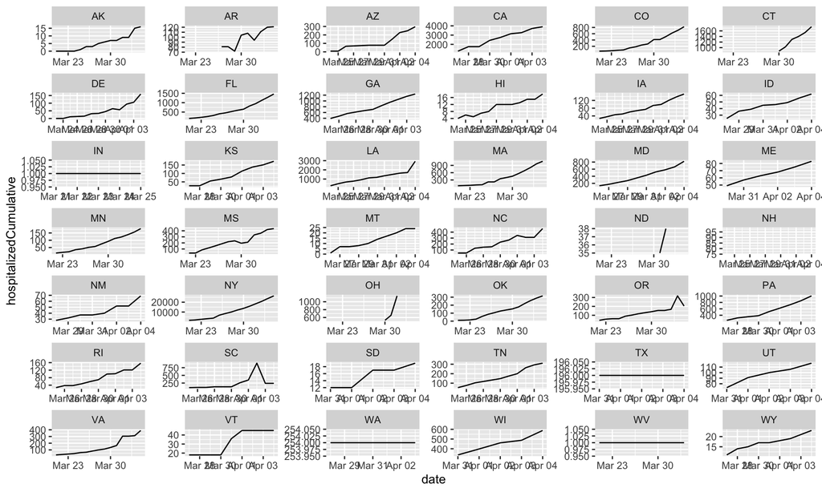

```r
state_ts[, state_n_obs := .N, by='state']
state_ts = state_ts[state_n_obs>=5][,state_n_obs := NULL]

ggplot(state_ts, aes(x=date, y=hospitalizedCumulative)) + geom_line() + facet_wrap(~state, scales = "free", ncol = 6)
```

Drop the stupid looking ones: AR, IN, ND, NH, OH, SC, SD, TX, VT, WA, WV

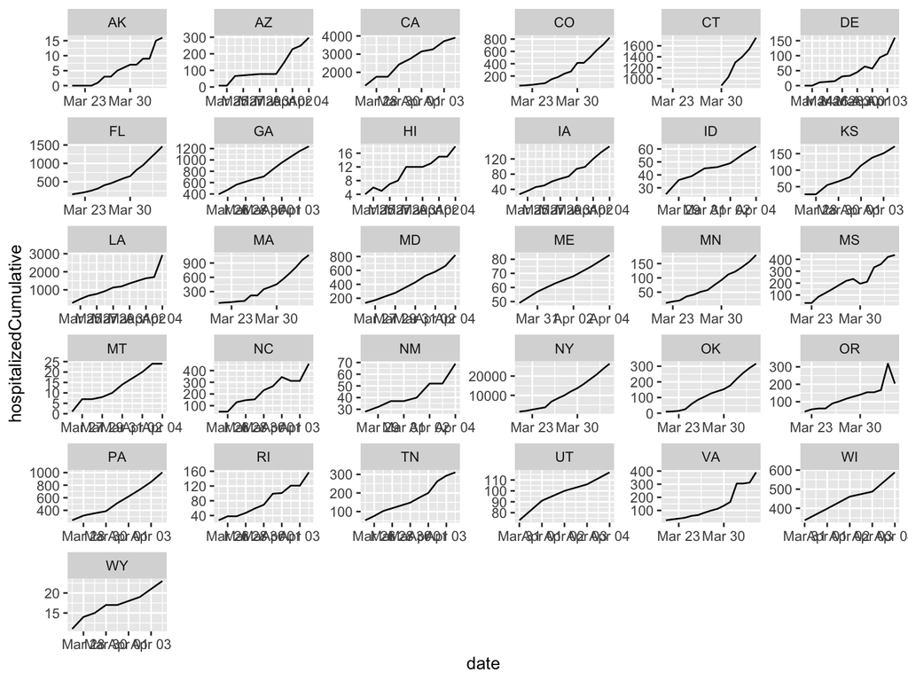

```r
state_ts = state_ts[!(state %in% c('AR', 'IN', 'ND', 'NH', 'OH', 'SC', 'SD', 'TX', 'VT', "WA", 'WV'))]
ggplot(state_ts, aes(x=date, y=hospitalizedCumulative)) + geom_line() + facet_wrap(~state, scales = "free", ncol = 6)
```

### Derive multiplier on cases by day and state to make actual hospitalizations equal expected hospitalizations

Expect cumulative hospitalizations to equal `exp_prop_cases_hos`*lag(positive, DAYS_FROM_SYMPTOMS_TO_HOSP)

```r
# Case time series
raw_case_dt = fread('data/daily-covidtracker-0404.csv')[,.(date = as.Date(as.character(date), format = '%Y %m %d'), state, positive)]
raw_case_dt[, hosp_date := date + DAYS_FROM_SYMPTOMS_TO_HOSP]
lagged_case_dt = raw_case_dt[,.(state, date = hosp_date, lagged_cases = positive)]

state_ts = merge(state_ts, lagged_case_dt, by = c('state', 'date'))
state_ts[, exp_cum_hosp := lagged_cases * exp_prop_cases_hos]
state_ts[state == "CA"] %>% kable() %>% kable_styling()
```

| state | date | state_population | exp_prop_cases_hos | positive | hospitalizedCumulative | imputed_cum_hos | lagged_cases | exp_cum_hosp |
| --- | --- | --- | --- | --- | --- | --- | --- | --- |
| CA | 2020-03-27 | 39148760 | 0.0661899 | 3879 | 1266 | TRUE | 1279 | 84.65689 |
| CA | 2020-03-28 | 39148760 | 0.0661899 | 4643 | 1755 | TRUE | 1536 | 101.66769 |
| CA | 2020-03-29 | 39148760 | 0.0661899 | 5708 | 1755 | TRUE | 1733 | 114.70710 |
| CA | 2020-03-30 | 39148760 | 0.0661899 | 6447 | 2430 | TRUE | 2102 | 139.13118 |
| CA | 2020-03-31 | 39148760 | 0.0661899 | 7482 | 2744 | TRUE | 2355 | 155.87723 |
| CA | 2020-04-01 | 39148760 | 0.0661899 | 8155 | 3148 | TRUE | 3006 | 198.96685 |
| CA | 2020-04-02 | 39148760 | 0.0661899 | 9191 | 3262 | TRUE | 3879 | 256.75064 |
| CA | 2020-04-03 | 39148760 | 0.0661899 | 10701 | 3714 | TRUE | 4643 | 307.31973 |
| CA | 2020-04-04 | 39148760 | 0.0661899 | 12026 | 3904 | TRUE | 5708 | 377.81198 |

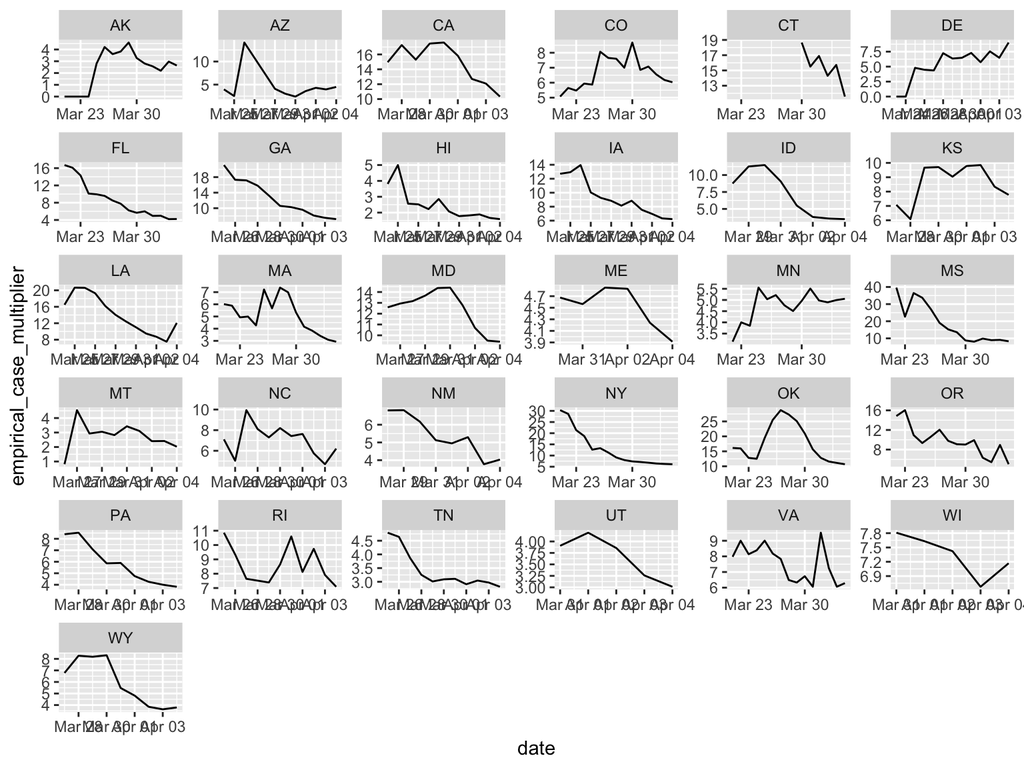

```r
state_ts[, empirical_case_multiplier := hospitalizedCumulative/exp_cum_hosp]

ggplot(state_ts, aes(x=date, y=empirical_case_multiplier)) + geom_line() + facet_wrap(~state, scales = "free", ncol = 6)
```

### Apply the derived multipliers to case time series by state and compare empirical and adjusted growth rates

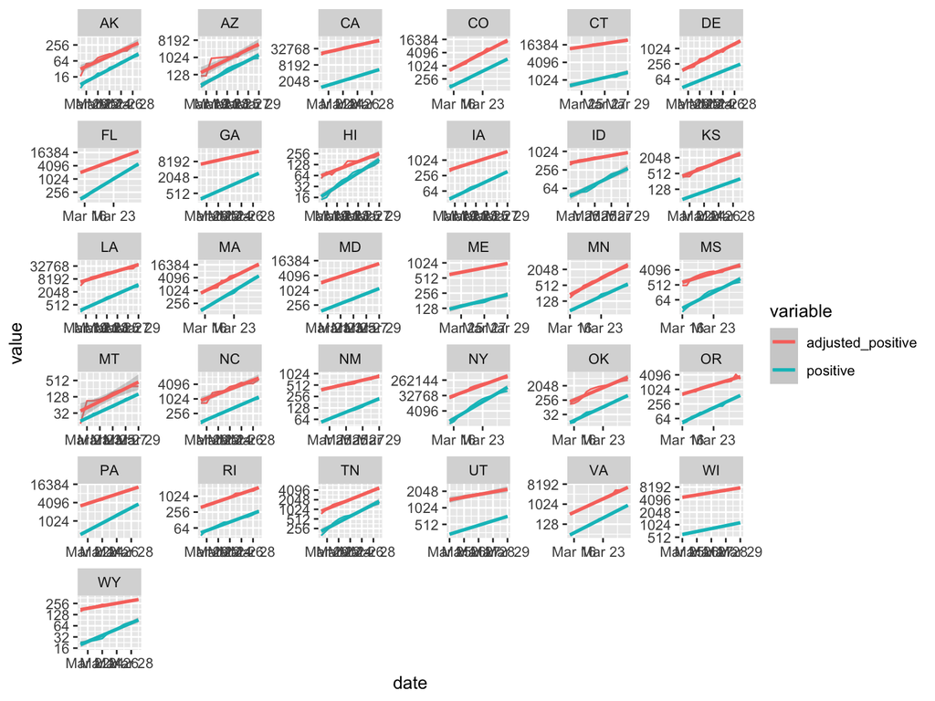

```r
mult_dt = state_ts[,.(state, hosp_date = date, empirical_case_multiplier)]

case_dt = merge(raw_case_dt, mult_dt, by = c('state', 'hosp_date'))

case_dt[, adjusted_positive := positive * empirical_case_multiplier]

case_dt = case_dt[positive>0 & adjusted_positive>0]

ggplot(
  melt(case_dt[,.(state, date, adjusted_positive, positive)], id.vars = c('state', 'date')),
  aes(x=date, y=value, color = variable)) + geom_line() + facet_wrap(~state, scales = "free", ncol = 6) +
  scale_y_continuous(trans='log2') + geom_smooth(method="lm")
```

```r
calculate_raw_and_adjusted_growth_rates = function(full_dt, s) {

  subset = full_dt[state == s]
  subset[, `:=`(
    log_2_raw_cases = log(positive, 2),
    log_2_adj_cases = log(adjusted_positive, 2),
    day = as.numeric(date - min(date))
    )]

  raw_coef = lm(log_2_raw_cases ~ day, data = subset)$coefficients[['day']]

  adj_coef = lm(log_2_adj_cases ~ day, data = subset)$coefficients[['day']]

  return(data.table(
    state = s,
    raw_coef = raw_coef,
    raw_dt = 1/raw_coef,
    adj_coef = adj_coef,
    adj_dt = 1/adj_coef
  ))
}

rbindlist(lapply(case_dt[,unique(state)], function(x) calculate_raw_and_adjusted_growth_rates(case_dt, x))) %>% kable() %>% kable_styling()
```

| state | raw_coef | raw_dt | adj_coef | adj_dt |
| --- | --- | --- | --- | --- |
| AK | 0.3856168 | 2.593248 | 0.3269181 | 3.058870 |
| AZ | 0.4796230 | 2.084971 | 0.4505924 | 2.219301 |
| CA | 0.2710070 | 3.689941 | 0.1984210 | 5.039788 |
| CO | 0.3069926 | 3.257407 | 0.3269363 | 3.058700 |
| CT | 0.2994571 | 3.339377 | 0.1958279 | 5.106525 |
| DE | 0.3044390 | 3.284731 | 0.3825318 | 2.614162 |
| FL | 0.3782962 | 2.643432 | 0.2303679 | 4.340883 |
| GA | 0.3212578 | 3.112765 | 0.1609529 | 6.212997 |
| HI | 0.3079652 | 3.247120 | 0.1855999 | 5.387933 |
| IA | 0.3202706 | 3.122359 | 0.2153121 | 4.644422 |
| ID | 0.4334699 | 2.306965 | 0.1592757 | 6.278420 |
| KS | 0.3267809 | 3.060154 | 0.3596481 | 2.780496 |
| LA | 0.3604374 | 2.774407 | 0.2425873 | 4.122228 |
| MA | 0.3849194 | 2.597946 | 0.3216632 | 3.108841 |
| MD | 0.3383464 | 2.955551 | 0.2858288 | 3.498597 |
| ME | 0.1916580 | 5.217626 | 0.1457033 | 6.863261 |
| MN | 0.2602138 | 3.842994 | 0.2927941 | 3.415370 |
| MS | 0.4556541 | 2.194647 | 0.2652563 | 3.769938 |
| MT | 0.3673990 | 2.721836 | 0.3941127 | 2.537345 |
| NC | 0.3431944 | 2.913800 | 0.3078194 | 3.248658 |
| NM | 0.2912744 | 3.433189 | 0.1689978 | 5.917235 |
| NY | 0.4714018 | 2.121333 | 0.2979642 | 3.356108 |
| OK | 0.4020649 | 2.487161 | 0.3679125 | 2.718038 |
| OR | 0.2837070 | 3.524763 | 0.1858814 | 5.379774 |
| PA | 0.4149173 | 2.410119 | 0.2551255 | 3.919640 |
| RI | 0.2690255 | 3.717119 | 0.2486289 | 4.022059 |
| TN | 0.3112968 | 3.212368 | 0.2411562 | 4.146690 |
| UT | 0.2693007 | 3.713321 | 0.1581206 | 6.324286 |
| VA | 0.3180828 | 3.143835 | 0.2876329 | 3.476654 |
| WI | 0.2337557 | 4.277971 | 0.1897288 | 5.270680 |
| WY | 0.2776034 | 3.602261 | 0.1129324 | 8.854854 |

### Load county case time series and apply state-date multipliers to get adjusted time series

```r
raw_county_ts = fread("https://raw.githubusercontent.com/nytimes/covid-19-data/master/us-counties.csv")
raw_county_ts = raw_county_ts[,.(State = state, date = as.Date(date), county, cases)]
raw_county_ts = merge(raw_county_ts, state_abbrev)
raw_county_ts = raw_county_ts[,.(state = Code, county_cases = cases, county, date)]
#raw_county_ts  %>% kable() %>% kable_styling()
```

```r
county_ts = merge(case_dt[,.(state, date, empirical_case_multiplier)],
                  raw_county_ts, by = c('state', 'date'))
county_ts[, adjusted_cases := county_cases * empirical_case_multiplier]
#county_ts  %>% kable() %>% kable_styling()
```

Plot some example counties. New York City, Los Angeles, Contra Costa, San Francisco, Santa Clara, San Mateo

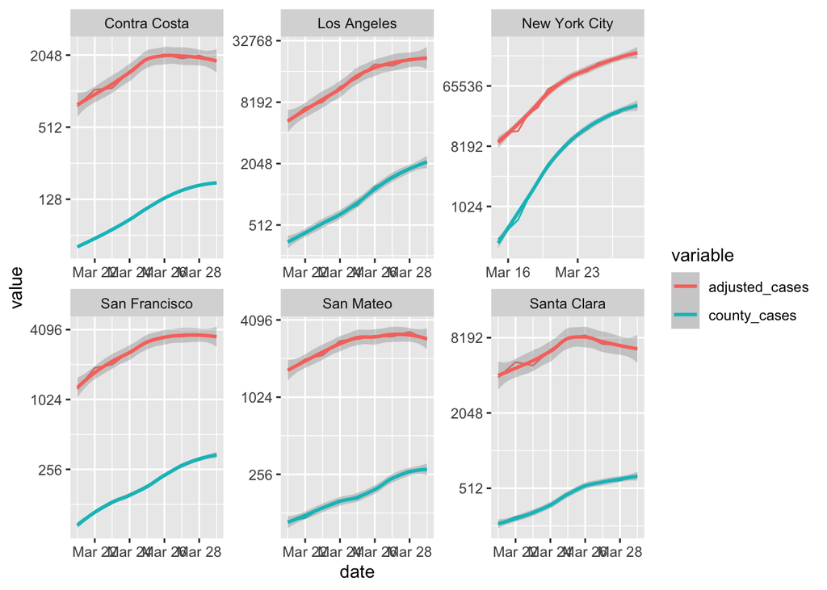

```r
#unique(county_ts[, .(county, state)])[state == "CA"]

ggplot(
  melt(county_ts[county %in% c('New York City', 'Los Angeles', 'Contra Costa', 'San Francisco', 'Santa Clara', 'San Mateo'),
                 .(county, date, adjusted_cases, county_cases)], id.vars = c('county', 'date')),
  aes(x=date, y=value, color = variable)) + geom_line() + facet_wrap(~county, scales = "free", ncol = 3) +
  scale_y_continuous(trans='log2') + geom_smooth()
```

Raw and adjusted doubling times

```r
calculate_raw_and_adjusted_growth_rates = function(full_dt, c) {

  subset = full_dt[county == c]
  subset[, `:=`(
    log_2_raw_cases = log(county_cases, 2),
    log_2_adj_cases = log(adjusted_cases, 2),
    day = as.numeric(date - min(date))
    )]

  raw_coef = lm(log_2_raw_cases ~ day, data = subset)$coefficients[['day']]

  adj_coef = lm(log_2_adj_cases ~ day, data = subset)$coefficients[['day']]

  return(data.table(
    county = c,
    raw_coef = raw_coef,
    raw_dt = 1/raw_coef,
    adj_coef = adj_coef,
    adj_dt = 1/adj_coef
  ))
}

rbindlist(lapply(c('New York City', 'Los Angeles', 'Contra Costa', 'San Francisco', 'Santa Clara', 'San Mateo'),
                 function(x) calculate_raw_and_adjusted_growth_rates(county_ts, x))) %>% kable() %>% kable_styling(bootstrap_options = c("striped", "hover"))
```

| county | raw_coef | raw_dt | adj_coef | adj_dt |
| --- | --- | --- | --- | --- |
| New York City | 0.4983562 | 2.006597 | 0.3249186 | 3.077694 |
| Los Angeles | 0.3416305 | 2.927139 | 0.2690445 | 3.716858 |
| Contra Costa | 0.2380726 | 4.200399 | 0.1654866 | 6.042785 |
| San Francisco | 0.2542546 | 3.933065 | 0.1816686 | 5.504528 |
| Santa Clara | 0.1714294 | 5.833305 | 0.0988434 | 10.117015 |
| San Mateo | 0.1798531 | 5.560094 | 0.1072671 | 9.322525 |